# rel4

Ruilin Peng

2025-12-16

# Load data from actigraph

```r
library(read.gt3x)
library(data.table)
gt3x_path1 <- "data/MOS2E48230454 (2025-12-04).gt3x"
gt3x_path2 <- "data/MOS2E48230491 (2025-12-04).gt3x"
gt3x_path3 <- "data/MOS2E48230815 (2025-12-04).gt3x"

lf <- read.gt3x(gt3x_path1, asDataFrame = TRUE, imputeZeroes = TRUE)
rf <- read.gt3x(gt3x_path2, asDataFrame = TRUE, imputeZeroes = TRUE)
rh <- read.gt3x(gt3x_path3, asDataFrame = TRUE, imputeZeroes = TRUE)
lf_df <- as.data.table(lf)
rf_df <- as.data.table(rf)
rh_df <- as.data.table(rh)
```

```r
# 1) Define the time window
start_time <- as.POSIXct("2025-12-04 15:41:06", tz = "UTC")
end_time   <- start_time + 5*60 + 8   # 5 minutes later

# 2) Make sure 'time' is POSIXct
dt_list <- list(lf_df, rf_df, rh_df)
for (i in seq_along(dt_list)) {
  dt_list[[i]][, time := as.POSIXct(time, tz = "UTC")]
}

lf_df <- dt_list[[1]]
rf_df <- dt_list[[2]]
rh_df <- dt_list[[3]]

# 3A) Keep ONLY that 5-minute window:
lf_df_5min <- lf_df[time >= start_time & time <= end_time]
rf_df_5min <- rf_df[time >= start_time & time <= end_time]
rh_df_5min <- rh_df[time >= start_time & time <= end_time]
```

We start by loading the full data from the actigraphs as data frames. After deciding the start time and the end time of motion capturing, we can manually filter the actigraph data to inspect only the selected time intervals.

```r
# Put them in a list to treat all three the same way
dt5_list <- list(lf_df_5min, rf_df_5min, rh_df_5min)

for (i in seq_along(dt5_list)) {
  dt5_list[[i]][,
    `:=`(
      # Euclidean magnitude (classic vector length)
      a_mag_g = sqrt(X^2 + Y^2 + Z^2)
    )
  ]
}

lf_df_5min <- dt5_list[[1]]
rf_df_5min <- dt5_list[[2]]
rh_df_5min <- dt5_list[[3]]
```

Then for each of the actigraph data, acceleration magnitude is computed as Euclidean magnitude(in g).

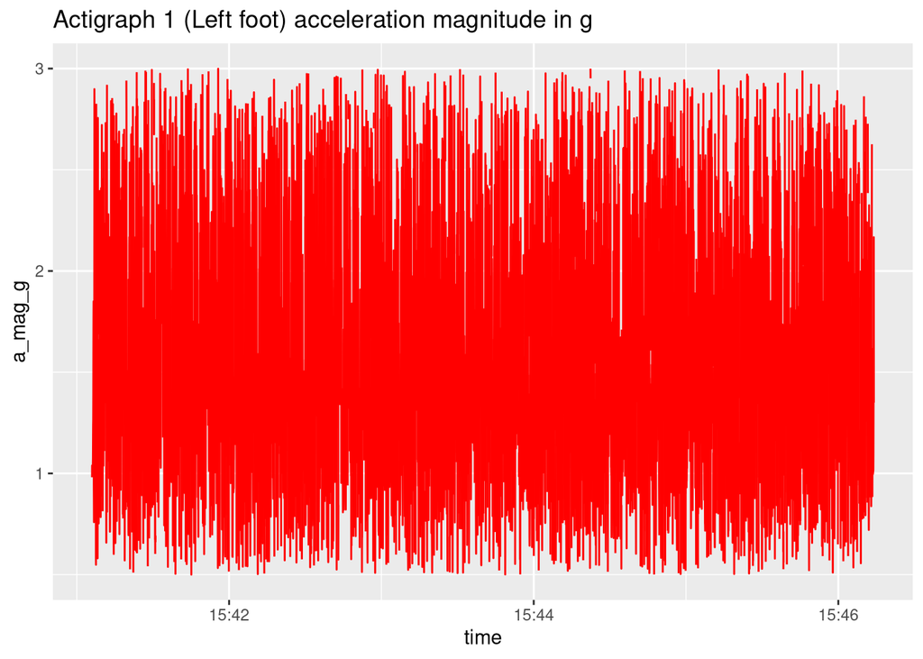

```r
lf_df_5min[ a_mag_g < 0.5 | a_mag_g > 3, a_mag_g := NA ]
rf_df_5min[ a_mag_g < 0.5 | a_mag_g > 3, a_mag_g := NA ]
rh_df_5min[ a_mag_g < 0.5 | a_mag_g > 3, a_mag_g := NA ]

library(ggplot2)
ggplot(lf_df_5min, aes(time, a_mag_g)) +
  geom_line(color="red") +
  ggtitle("Actigraph 1 (Left foot) acceleration magnitude in g")
```

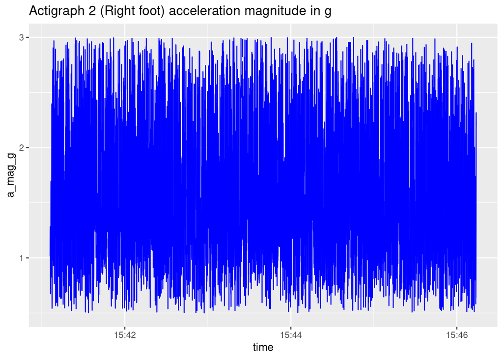

```r
ggplot(rf_df_5min, aes(time, a_mag_g)) +
  geom_line(color="blue") +
  ggtitle("Actigraph 2 (Right foot) acceleration magnitude in g")
```

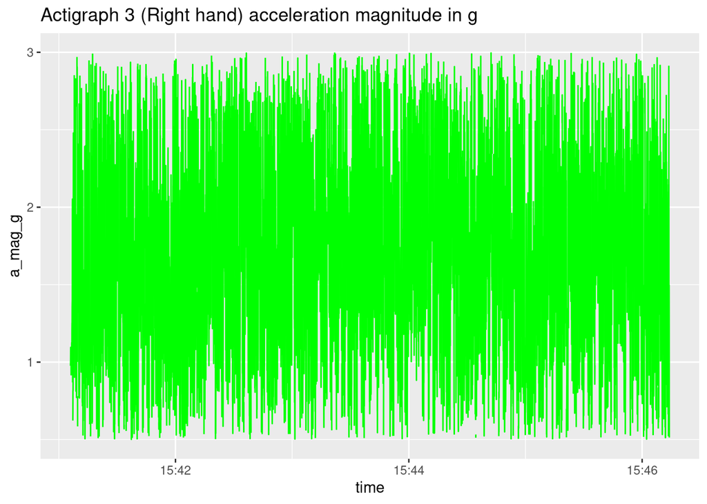

```r
ggplot(rh_df_5min, aes(time, a_mag_g)) +
  geom_line(color="green") +
  ggtitle("Actigraph 3 (Right hand) acceleration magnitude in g")
```

Since the normal acceleration of human running does not exceed 3g, we cleaned out any acceleration above 3g as outliers and the above diagrams display the final timeseries of the actigraphs.

# Data Loading from freemocap regarding right foot

```r
library(read.gt3x)
library(data.table)

df <- fread("data/recording_15_41_06_gmt+8_by_trajectory.csv")

cols_keep <- c(
  "timestamp",
  "com_right_foot_x", "com_right_foot_y", "com_right_foot_z"
)

df <- df[, ..cols_keep]
```

```r
df[, t := (timestamp - timestamp[1]) / 1e9]
```

```r
setDT(df)
# anchor time: same as your IMU series
anchor_time <- as.POSIXct("2025-12-04 15:41:06", tz = "UTC")
# helper: build absolute time from dt (sec differences)
make_time_from_dt <- function(dt_vec, t0) {
  # replace NA in first row with 0
  dt_clean <- ifelse(is.na(dt_vec), 0, dt_vec)
  t0 + dt_clean
}
df[, time := make_time_from_dt(t, anchor_time)]
```

Similarly for motion captured data from FreeMocap, we start by loading the full data as a dataframe but then filter whem into only the columns we are trying to inspect(For example, right foot coordinates in this case).

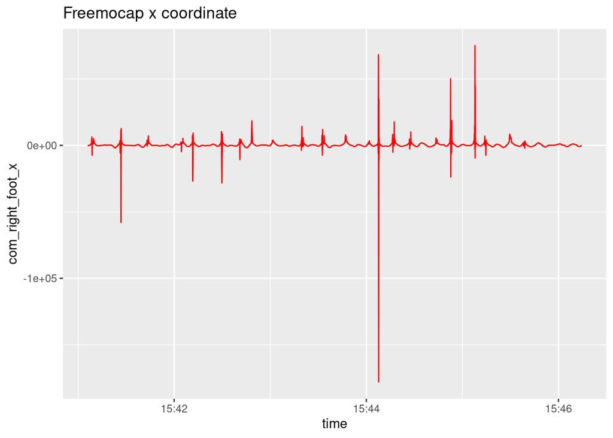

```r
ggplot(df, aes(time, com_right_foot_x)) +
  geom_line(color="red") +
  ggtitle("Freemocap x coordinate")
```

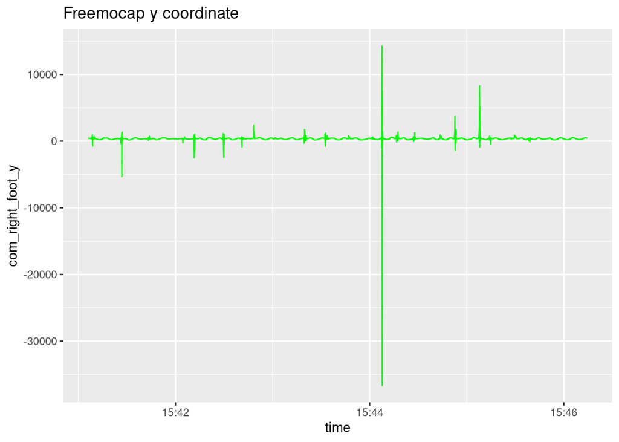

```r
ggplot(df, aes(time, com_right_foot_y)) +
  geom_line(color="green") +
  ggtitle("Freemocap y coordinate")
```

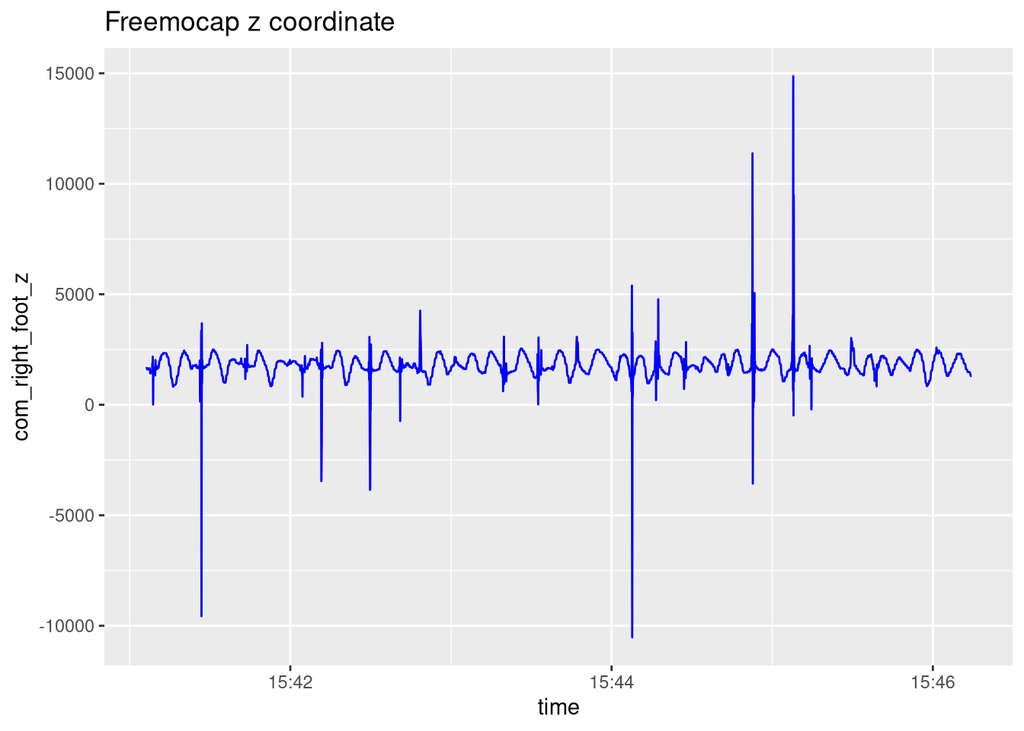

```r
ggplot(df, aes(time, com_right_foot_z)) +
  geom_line(color="blue") +
  ggtitle("Freemocap z coordinate")
```

Visualization shows clear outliers, so we starts by removing them.

```r
remove_outliers_mad <- function(x, k = 6) {
  med  <- median(x, na.rm = TRUE)
  madv <- mad(x, constant = 1, na.rm = TRUE)
  dev  <- abs(x - med)

  x[dev > k*madv] <- NA
  return(x)
}
```

We first assign NA to data points whose deviation is greater than 6 MADs(Median Absolute Deviation) away from the median

```r
df[, com_right_foot_x := remove_outliers_mad(com_right_foot_x)]
df[, com_right_foot_y := remove_outliers_mad(com_right_foot_y)]
df[, com_right_foot_z := remove_outliers_mad(com_right_foot_z)]
```

```r
library(zoo)
df[, com_right_foot_x := na.approx(com_right_foot_x, na.rm = FALSE)]
df[, com_right_foot_y := na.approx(com_right_foot_y, na.rm = FALSE)]
df[, com_right_foot_z := na.approx(com_right_foot_z, na.rm = FALSE)]
```

Then we incorporate missing values.

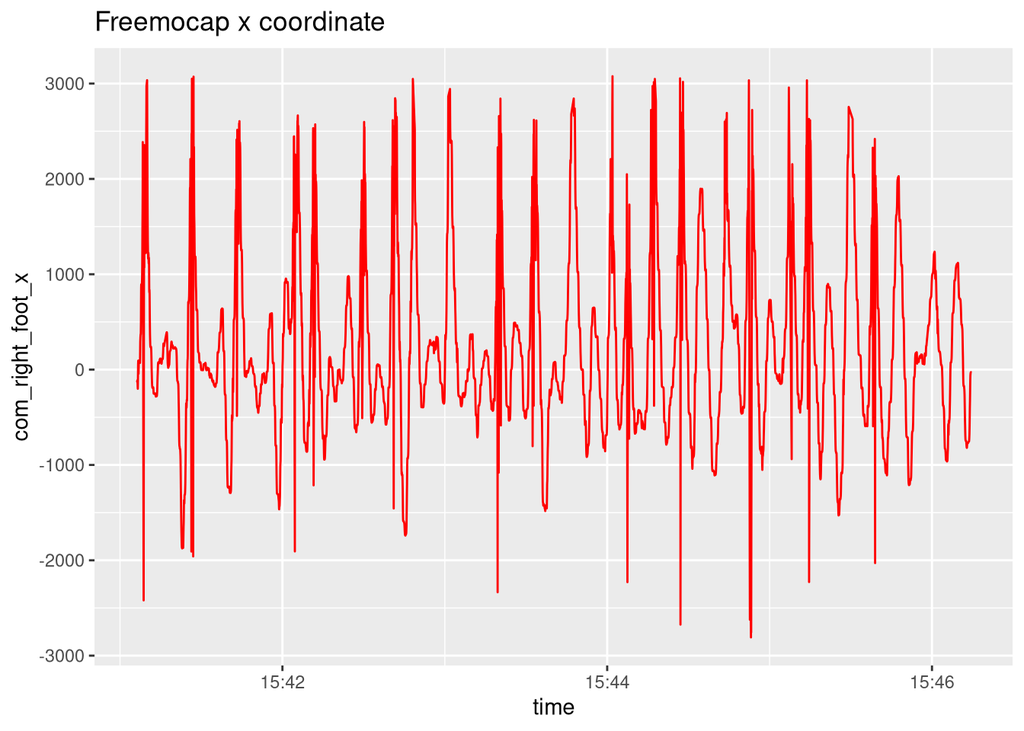

```r
ggplot(df, aes(time, com_right_foot_x)) +
  geom_line(color="red") +
  ggtitle("Freemocap x coordinate")
```

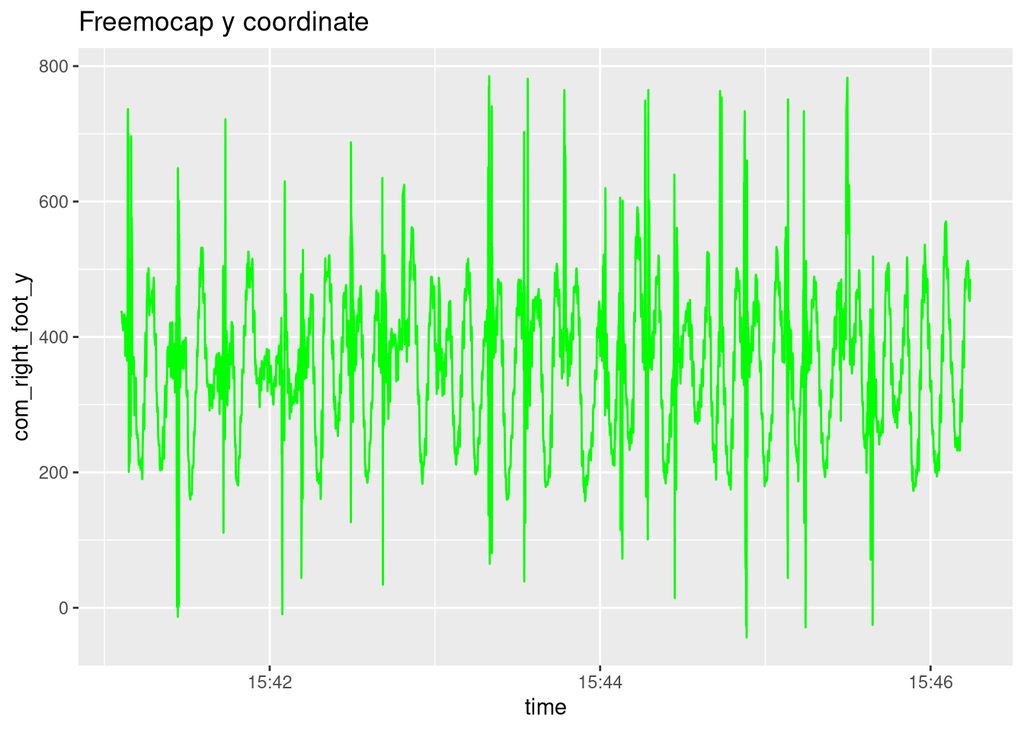

```r
ggplot(df, aes(time, com_right_foot_y)) +
  geom_line(color="green") +
  ggtitle("Freemocap y coordinate")
```

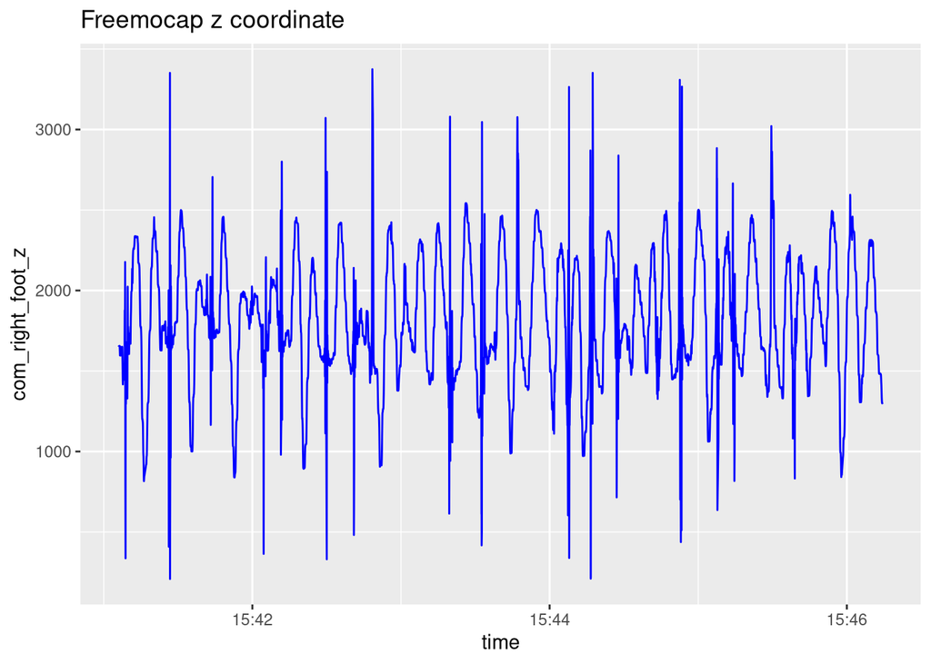

```r
ggplot(df, aes(time, com_right_foot_z)) +
  geom_line(color="blue") +
  ggtitle("Freemocap z coordinate")
```

```r
setDT(df)

# sort by time just in case
setorder(df, t)

# velocity (m/s)
df[, `:=`(
  vx = c(NA, diff(com_right_foot_x) / (1000*diff(t))),
  vy = c(NA, diff(com_right_foot_y) / (1000*diff(t))),
  vz = c(NA, diff(com_right_foot_z) / (1000*diff(t)))
)]

# acceleration (m/s^2)
df[, `:=`(
  ax = c(NA, diff(vx) / diff(t)),
  ay = c(NA, diff(vy) / diff(t)),
  az = c(NA, diff(vz) / diff(t))
)]

g_const <- 9.81

df[, a_mag_g := sqrt(ax^2 + ay^2 + az^2) / g_const + 1]
```

```r
df[
  a_mag_g < 0.5 |
  a_mag_g > 3,
  a_mag_g := NA
]
```

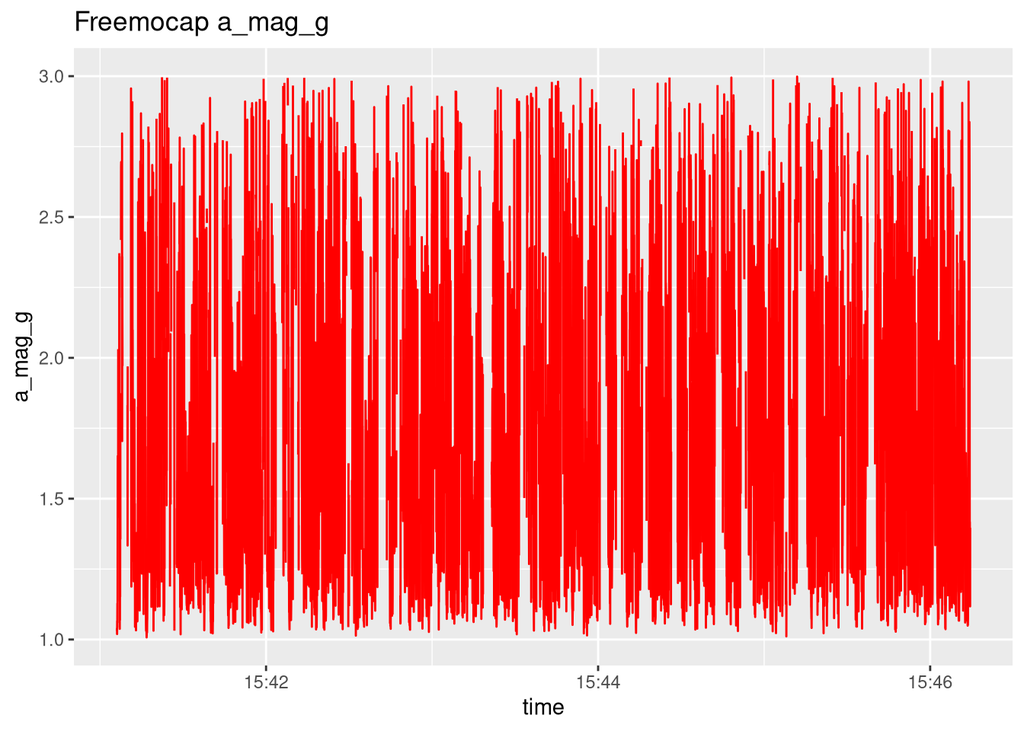

```r
ggplot(df, aes(time, a_mag_g)) +
  geom_line(color="red") +
  ggtitle("Freemocap a_mag_g")
```

Then we compute accelerations, by differentiating each dimension twice over time difference, and then compute into a Eucilidean magnitude as well. Similarly, any magnitude above 3g was considered outliers and removed.

# 1 sec window

```r
df[, sec := floor(as.numeric(time))]

fmc_win <- df[
  , .(a = mean(a_mag_g, na.rm = TRUE)),
  by = sec
]

rf_df_5min[, sec := floor(as.numeric(time))]

ag_win <- rf_df_5min[
  , .(a = mean(a_mag_g, na.rm = TRUE)),
  by = sec
]
```

```r
common_sec <- intersect(fmc_win$sec, ag_win$sec)

fmc_aligned <- fmc_win[sec %in% common_sec][order(sec)]
ag_aligned  <- ag_win[sec %in% common_sec][order(sec)]

valid <- complete.cases(fmc_aligned$a, ag_aligned$a)

x <- fmc_aligned$a[valid]
y <- ag_aligned$a[valid]
```

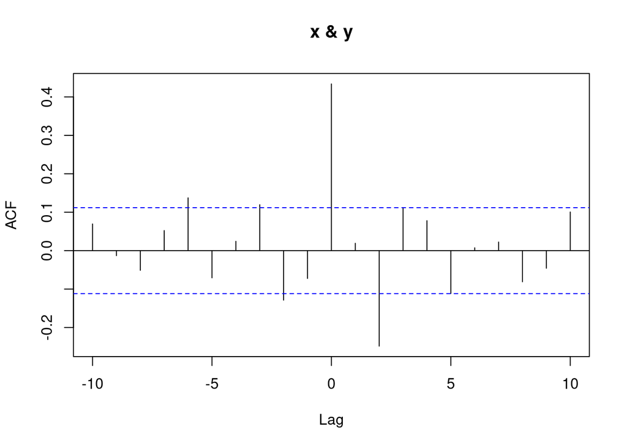

```r
x <- as.numeric(scale(x))
y <- as.numeric(scale(y))


cc <- ccf(
  x,
  y,
  lag.max = 10,   # ±10 seconds
  plot = TRUE
)
```

Lastly, we put data points into bins(of each second) and compute the mean of each bin. Scaling was also performed so we have 2 series of z-scores for comparisons. Then, cross correlation analysis was performed.

```r
peak_idx <- which.max(abs(cc$acf))
peak_lag <- cc$lag[peak_idx]
peak_r   <- cc$acf[peak_idx]
```

```r
peak_idx
```

```
## [1] 11
```

```r
peak_lag
```

```
## [1] 0
```

```r
peak_r
```

```
## [1] 0.4336781
```

```r
cor(x,y)
```

```
## [1] 0.4336781
```

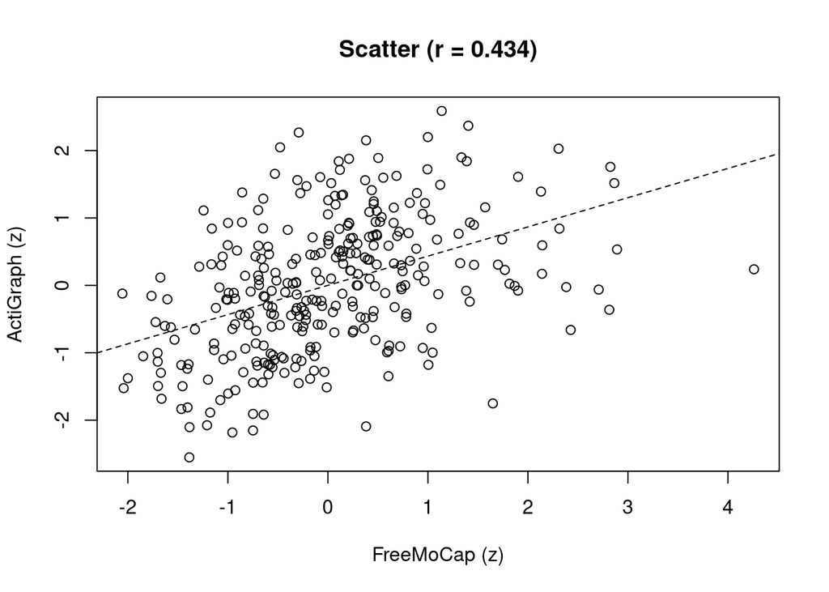

```r
plot(x, y, xlab = "FreeMoCap (z)", ylab = "ActiGraph (z)",
     main = sprintf("Scatter (r = %.3f)", cor(x, y)))
abline(lm(y ~ x), lty = 2)
```

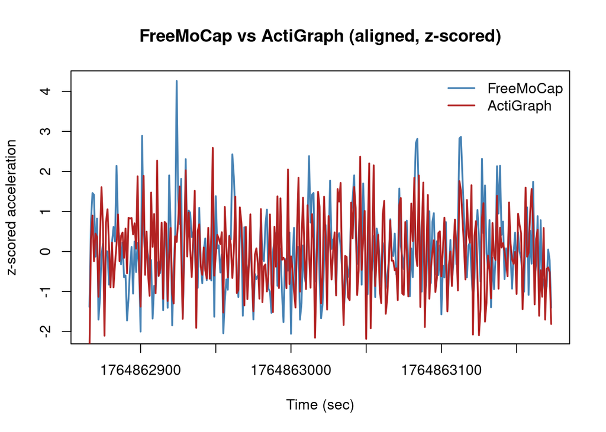

```r
sec_v <- fmc_aligned$sec[valid]

plot(
  sec_v, x,
  type = "l",
  col  = "steelblue",
  lwd  = 2,
  xlab = "Time (sec)",
  ylab = "z-scored acceleration",
  main = "FreeMoCap vs ActiGraph (aligned, z-scored)"
)

lines(
  sec_v, y,
  col = "firebrick",
  lwd = 2
)

legend(
  "topright",
  legend = c("FreeMoCap", "ActiGraph"),
  col    = c("steelblue", "firebrick"),
  lty    = 1,
  lwd    = 2,
  bty    = "n"
)
```

As final result, lag at 0 is shown to have the peak pearson correlation r=0.434, which is interpreted as moderate positive correlation.